# 第一章 Java入门

## 内容与目标

1. Java简介 (了解)
2. 通过JDK、IDE、jupyter 3种方式运行java代码 (**掌握，重点**)

## 1. Java简介

**1.1 课程考核**

期末闭卷60％+平时成绩40％  
平时成绩：课堂表现(出勤)、作业

**1.2 学习小组**

分为15组：每组4人，其中1组5人；每组设一名小组长；辛苦班委做一个Excel表格把分组情况发我。  
每组负责1周课程：

- 当周上课要讲的内容，要提前多下功夫，熟练掌握；
- 在课堂练习时负责给周围同学答疑，并记录答疑要点(同学碰到的主要问题)；

**1.3 学习资源(特别提醒：务必小心网站中的广告！)**

- 教材及其实验指导书
- https://www.liaoxuefeng.com/wiki/1252599548343744
- https://www.geeksforgeeks.org/java/?ref=lbp
- https://www.javatpoint.com/java-tutorial
- https://www.w3schools.com/java/default.asp (可在线运行代码)

**1.4 课程内容**

[figure not shown]

**1.5 了解Java**

- Java是一门面向对象的编程语言。
- 生日：1995年5月23日。

[figure not shown]

- 生父：James Gosling 詹姆斯·高斯林 (生于1955年)

[figure not shown]

- 语言排名：https://www.tiobe.com/tiobe-index/
- 重要性： <Should you still LEARN Java in 2023>

[figure not shown]

## 2. 三种方式运行Java代码

通过JDK、IDE、jupyter 3种方式运行java代码 (掌握，重点)

[figure not shown]

**2.1 JDK(命令行)运行代码**

(1) 准备工作：安装JDK

[figure not shown]

(2) 步骤(即Java程序的开发步骤)

```java
public class Hello {
   public static void main (String args[]) {
      System.out.println("大家好!");
      System.out.println("Nice to meet you");
      Student stu = new Student();
      stu.speak("We are students");
   }
}
class Student {
   public void speak(String s) {
      System.out.println(s);
   }
}
```

- 编写源文件： 打开文本文档，输入以上代码。文件名为 Hello.java
- 编译源文件： 打开终端窗口(cmd)，输入命令 javac Hello.java
- 运行字节码文件： 终端窗口输入命令 java Hello

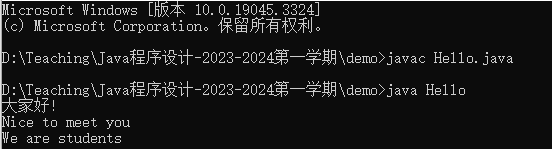

(3) 概念

- 源文件(Hello.java)、字节码文件(Hello.class、Student.class)
- 编译器(javac)、解释器(java)

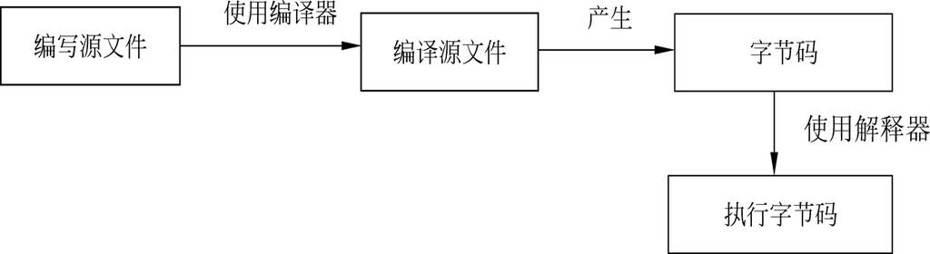

- 以下几个概念，先记住，无须理解：  
  (1) 类：一个class就是一个类，一个源文件可以有多个类。  
  (2) 主类：main方法所在的类称为主类。  
  (3) public类：有public修饰的类称为public类。一个源文件最多有1个public类。

**2.2 集成开发环境(IDE)运行代码**

(1) 准备工作:安装Eclipse

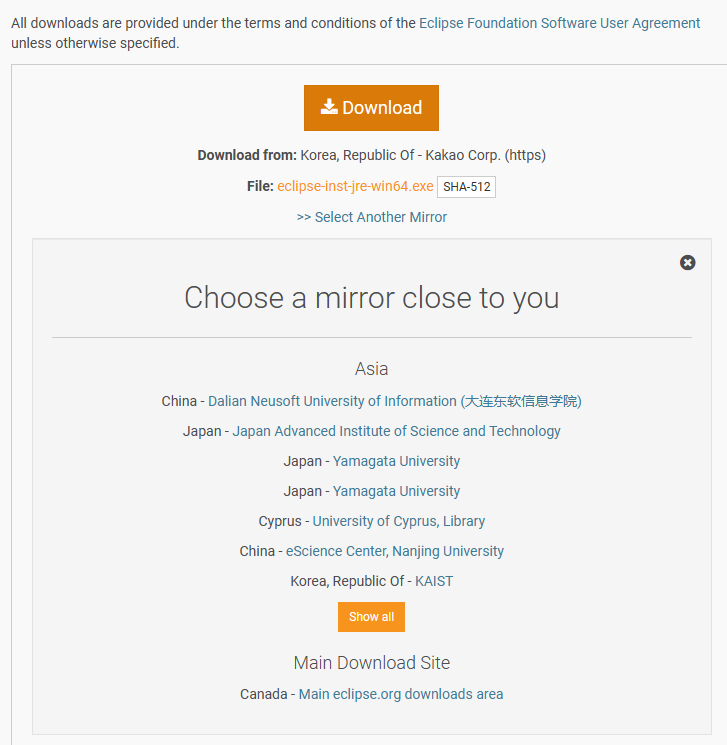

(2) 步骤

- 新建项目：File--New--Java Project
- 新建源文件： File--New--Class
- 运行源文件: Run

[figure not shown]

(3) 注释

- 编译器忽略注释内容，注释的目的是有利于代码的维护和阅读，因此给代码增加注释是一个良好的编程习惯。
- Java支持两种格式的注释：单行注释和多行注释  
  单行注释使用"//"表示单行注释的开始，即该行中从"//"开始的后续内容为注释  
  多行注释的使用"/*"表示注释的开始，以"*/"表示注释结束 .

(4) 常见用法和设置

- 熟悉Eclipse环境的各个窗口。
- Alt+/ 代码提醒， Ctrl+Z 撤销上一步操作
- 字体字号大小-Preferences--General—Appearance—Colors and Fonts---Java Editor Text Fonts
- 编程风格--------Preference—General—Appearance—Theme
- 打开命令行窗口： Terminal---点击右上角小电视窗口
- 如果出现中文字符无法显示，需要设置中文的编码格式：Run-Run Configurations-- Common--Encoding--GBK
- JDK, JRE, JVM, JSE, JEE, JME 几个缩写词区别(了解)

https://jse.readthedocs.io/en/latest/jdk8/jdkJre.html

**2.3 Jupyter运行代码**

(1) 准备工作

- 安装Python
- 安装Jupyter Notebook

网址：https://blog.csdn.net/Withadream/article/details/125440035  
安装：在命令行窗口输入 pip install jupyter

- 安装ijava

网址：https://github.com/SpencerPark/IJava/releases  
安装：在上述网址下载 ijava-1.3.0.zip， 解压之后在当前文件夹打开命令行窗口，输入 py install.py 即可

(2) 步骤

- 启动Jupyter Notebook: 命令行窗口输入 Jupyter Notebook
- New--Java
- 更多介绍参见 https://zhuanlan.zhihu.com/p/33105153
- 注意将main方法及其所在的类名删掉，再运行程序。

## 小结

- Java程序的开发步骤

(1) 编写源文件: 扩展名必须是 .java。  
(2) 编译Java源程序: 用Java编译器（javac.exe）编译源文件，得到字节码文件 .class。  
(3) 运行Java程序: 使用Java解释器（java.exe）来解释执行字节码文件。

## 课堂练习

(1) 用命令行、IDE、Jupyter三种方式运行以下程序

```java
public class People {
    int height;
    String ear;
    void speak(String s) {
       System.out.println(s);
    }
}


class A {
    public static void main(String args[]) {
      People zhubajie;
      zhubajie = new People();
      zhubajie.height = 170;
      zhubajie.ear = "两只大耳朵";
      System.out.println("身高:"+zhubajie.height);
      System.out.println(zhubajie.ear);
      zhubajie.speak("师傅,咱们别去西天了,改去月宫吧");
    }
}
```

```java
public class People {
    int height;
    String ear;
    void speak(String s) {
       System.out.println(s);
    }
}



      People zhubajie;
      zhubajie = new People();
      zhubajie.height = 170;
      zhubajie.ear = "两只大耳朵";
      System.out.println("身高:"+zhubajie.height);
      System.out.println(zhubajie.ear);
      zhubajie.speak("师傅,咱们别去西天了,改去月宫吧");
```

```
身高:170
两只大耳朵
师傅,咱们别去西天了,改去月宫吧
```

(2) 请按模板要求将【代码】替换为Java程序代码。并用命令行、IDE、Jupyter三种方式运行程序。

```java
public class Hello
{   public static void main (String args[ ])
     {  //【代码1】    //命令行窗口输出"你好，很高兴学习Java"
         A a=new A();
         a.fA();
     }
}
class A
{    void fA()
      {  //【代码2】    //命令行窗口输出"We are students"
      }
}
```

(3) 请按模板要求将【代码】替换为Java程序代码。并用命令行、IDE、Jupyter三种方式运行程序。

```java
public class A {
  void fA() {
   //  【代码2】    //命令行窗口输出"I am A"
   }
}

public class B {
  void fB() {
    // 【代码3】    //命令行窗口输出"I am B"
   }
}

public class C {
  void fC() {
   //  【代码4】    //命令行窗口输出"I am C"
   }
}

public class MainClass {
    public static void main (String args[ ]) {
     //  【代码1】    //命令行窗口输出"你好，只需编译我"
        A a = new A();
        a.fA();
        B b = new B();
        b.fB();
     }
}
```

## 课后作业

一、问答题

1. Java语言的主要贡献者是谁？
2. 开发Java应用程序需要经过哪些主要步骤？
3. Java源文件是由什么组成的？一个源文件中必须要有public类吗？
4. Java源文件的扩展名是什么？Java字节码的扩展名是什么？

二、选择题

1. 下列哪个是JDK提供的编译器？

A) java.exe  
B) javac.exe  
C) javap.exe  
D) javaw.exe

2. 下列哪个是Java应用程序主类中正确的main方法？

A) public void main (String args[ ])  
B) static void main (String args[ ])  
C) public static void Main (String args[])  
D) public static void main (String args[ ])

三、阅读程序 阅读下列Java源文件，并回答问题。

```java
public class Person {
   void speakHello() {
      System.out.print("您好，很高兴认识您");
System.out.println(" nice to meet you");
   }
}
class Xiti {
   public static void main(String args[]) {
      Person zhang = new Person();
      zhang.speakHello();
    }
}
```

（a）上述源文件的名字是什么？  
（b）编译上述源文件将生成几个字节码文件？这些字节码文件的名字都是什么？  
（c）在命令行执行java Person得到怎样的错误提示？执行java xiti得到怎样的错误提示？ 执行java Xiti.class得到怎样的错误提示？执行java Xiti得到怎样的输出结果？